# R Notebook

### 3.3) The variable “age”

```r
summary(db.adult$age)
```

```
   Min. 1st Qu.  Median    Mean 3rd Qu.    Max.
  17.00   28.00   37.00   38.44   47.00   90.00
```

```r
IQR(db.adult$age)
```

```
[1] 19
```

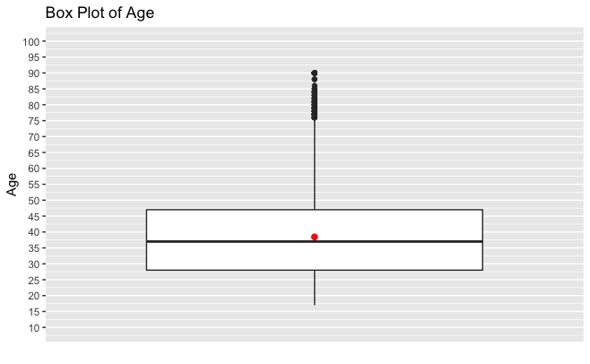

```r
ggplot(mapping = aes(x = factor(0), y = age),
       data = db.adult) +
  geom_boxplot() +
  stat_summary(fun.y = mean,
               geom = 'point',
               shape = 19,
               color = "red",
               cex = 2) +
  coord_cartesian(ylim = c(10, 100)) +
  scale_y_continuous(breaks = seq(10, 100, 5)) +
  ylab("Age") +
  xlab("") +
  ggtitle("Box Plot of Age") +
  scale_x_discrete(breaks = NULL)
```

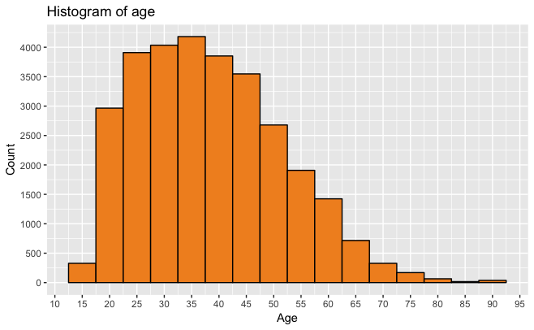

```r
qplot( x = db.adult$age,
       data = db.adult,
       binwidth = 5,
       color = I('black'),
       fill = I('#F29025'),
       xlab = "Age",
       ylab = "Count",
       main = "Histogram of age") +
  scale_x_continuous(breaks = seq(0, 95, 5)) +
  scale_y_continuous(breaks = seq(0, 4500, 500))
```

Next we display the empirical density of age grouped by income. From the plot we see that the majority of people earning more than 50K a year are between 33 and 55 years old, whereas the the greater number of people who earn less than 50K a year are between 18 and 45:

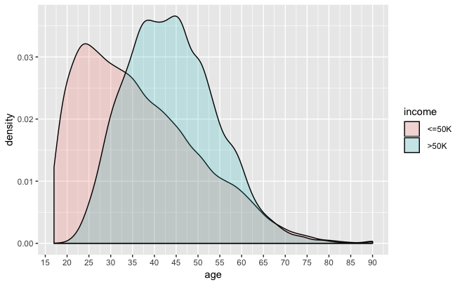

```r
ggplot(data = db.adult, aes(age, fill = income)) +
  geom_density(alpha = 0.2) +
  scale_x_continuous(breaks = seq(0, 95, 5))
```

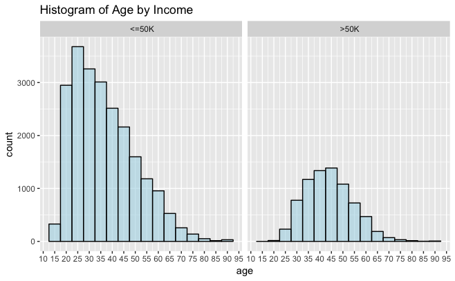

```r
ggplot(data = db.adult, mapping = aes(x = age)) +
  geom_histogram(binwidth = 5,
                 color = "black",
                 fill = "lightblue",
                 alpha = 0.6) +
  scale_x_continuous(breaks = seq(0, 95, 5)) +
  facet_wrap(~income) +
  ggtitle("Histogram of Age by Income")
```

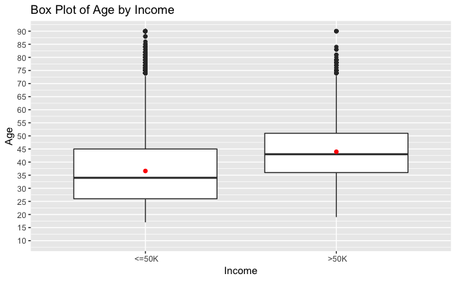

```r
ggplot(aes(x = income, y = age),
       data = db.adult) +
  geom_boxplot() +
  stat_summary(fun.y = mean,
               geom = "point",
               shape = 16,
               cex = 2,
               col = "red") +
  coord_cartesian(ylim = c(10, 90))+
  scale_y_continuous(breaks = seq(10, 90, 5)) +
  ylab("Age") +
  xlab("Income") +
  ggtitle("Box Plot of Age by Income")
```

In the box plot above, the filled red dot represents the mean value and the black horizontal line is the median. Once again we see the relationship between age and income. People who earn more that 50K a year are on average about 43-44 years old, whereas people who earn less than 50K a year, are younger on average - around 34-37. This can be also be seen by the summary statistics below:

```r
summary(subset(db.adult$age, db.adult$income == " <=50K"))
```

```
   Min. 1st Qu.  Median    Mean 3rd Qu.    Max.
  17.00   26.00   34.00   36.61   45.00   90.00
```

```r
summary(subset(db.adult$age, db.adult$income == " >50K"))
```

```
   Min. 1st Qu.  Median    Mean 3rd Qu.    Max.
  19.00   36.00   43.00   43.96   51.00   90.00
```

From the above output and the box plots we also notice that the first quartiles (25-th percentiles) for both groups differ significantly. The first quartile for people who have an income of more than 50K is equal to 36, whereas the first quartile for people earning less than 50K equals 26. This means that the elder an individual is, the bigger their chances of having a higher income are. This can be explained by the fact that the older one gets, the more experienced professionally they become, which usually means a higher salary.

Below we show one more plot in order to demonstrate the correlation between age and income. We display a conditional density plot of income versus age:

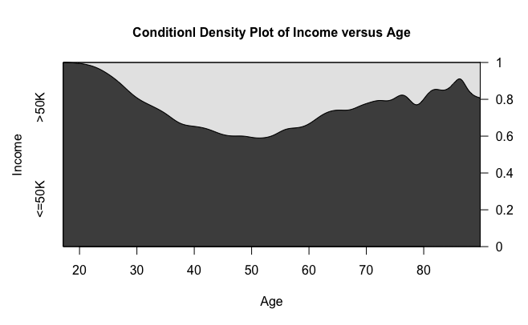

```r
cd_plot(x = db.adult$age,
        y = db.adult$income,
        xlab = "Age",
        ylab = "Income",
        main = "Conditionl Density Plot of Income versus Age")
```

Finally, we show a plot of mean working hours per week versus age, grouped by gender. From this graph we see that on average men work more hours per week than women at almost all ages. There is an exception for people between 77 and 80 and between 85 and 90, where women have more working hours per week on average. However, the latter observations are outliers (data which are highly unlikely for this study, because it is very unusual for people to work when they are above 80 years old), we have to consider these extreme data points with caution. We also notice that the mean number of woring hours per week for people between 25 and 60 years old (active working years) is 40 hours for women and 45 hours for men. For people above 65 years old the average working hours per week gradually decrease and vary between about 15 and 30 hours.

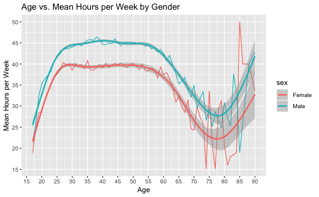

```r
ggplot(aes(x = age, y = hours_per_week),
       data = db.adult) +
  geom_line(mapping = aes(color = sex),
            stat = 'summary',
            fun.y = mean) +
  geom_smooth(mapping = aes(color = sex)) +
  scale_x_continuous(breaks = seq(10, 100, 5)) +
  scale_y_continuous(breaks = seq(0, 55, 5)) +
  labs(x = "Age", y = "Mean Hours per Week") +
  ggtitle("Age vs. Mean Hours per Week by Gender")
```

#### 3.4) The variables “hours_per_week” and “hours_w”

#### 3.4.1) “hours_per_week”

```r
summary(db.adult$hours_per_week)
```

```
   Min. 1st Qu.  Median    Mean 3rd Qu.    Max.
   1.00   40.00   40.00   40.93   45.00   99.00
```

```r
IQR(db.adult$hours_per_week)
```

```
[1] 5
```

The mean number of working hours per week is 41 and at least 50% of the participants in the study work between 40 and 45 hours a week. Next we show the box plot of “hours_per_week” which visualizes the summary statistic. We see that there are many outliers, i.e. there are many people who work less than 40 hours a week or more than 45 hours a week:

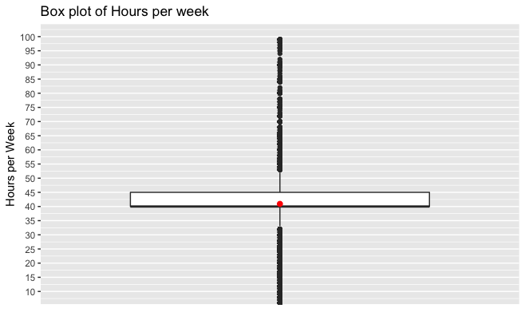

```r
ggplot(aes(x = factor(0), y = hours_per_week),
       data = db.adult) +
  geom_boxplot() +
  stat_summary(fun.y = mean,
               geom = "point",
               shape = 19,
               color = "red",
               cex = 2) +
  coord_cartesian(ylim = c(10, 100)) +
  scale_x_discrete(breaks = NULL) +
  scale_y_continuous(breaks = seq(10, 100, 5)) +
  ylab("Hours per Week") +
  xlab("") +
  ggtitle("Box plot of Hours per week")
```

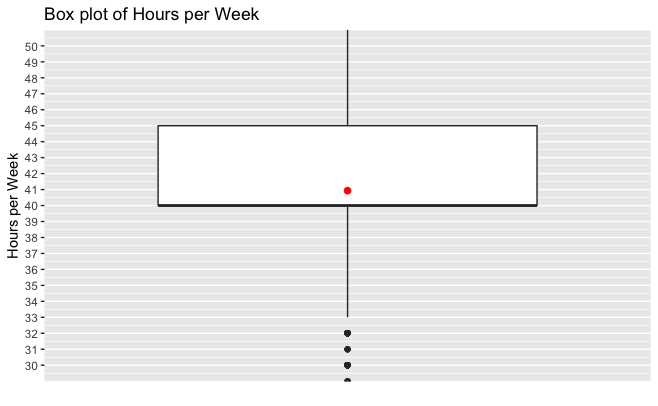

```r
# Zoomed box plot of hours per week:
ggplot(aes(x = factor(0), y = hours_per_week),
       data = db.adult) +
  geom_boxplot() +
  stat_summary(fun.y = mean,
               geom = "point",
               color = "red",
               shape = 19,
               cex = 2) +
  coord_cartesian(ylim = c(30, 50)) +
  scale_x_discrete(breaks = NULL) +
  scale_y_continuous(breaks = seq(30, 50, 1)) +
  ylab("Hours per Week") +
  xlab("") +
  ggtitle("Box plot of Hours per Week")
```

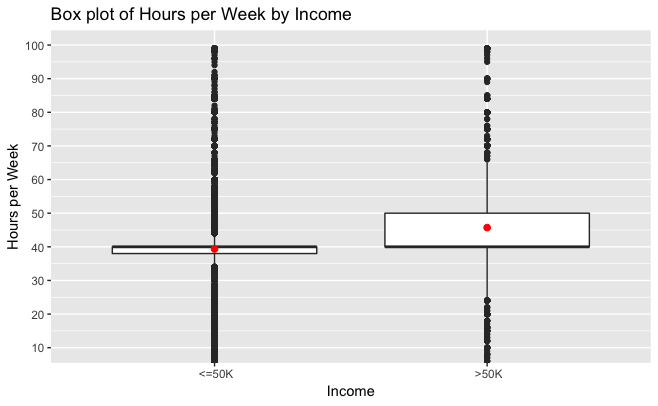

```r
ggplot(aes(x = income, y = hours_per_week),
       data = db.adult) +
  geom_boxplot() +
  stat_summary(fun.y = mean,
               geom = 'point',
               shape = 19,
               color = "red",
               cex = 2) +
  coord_cartesian( ylim = c(10, 100)) +
  scale_y_continuous(breaks =  seq(10, 100, 10)) +
  xlab("Income") +
  ylab("Hours per Week") +
  ggtitle("Box plot of Hours per Week by Income")
```

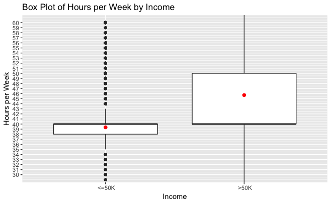

```r
# Zoom of the box plot of hours per week by income:
ggplot(aes(x = income, y = hours_per_week),
       data = db.adult) +
  geom_boxplot() +
  stat_summary(fun.y = mean,
               geom = 'point',
               shape = 19,
               color = "red",
               cex = 2) +
  coord_cartesian(ylim = c(30, 60))+
  scale_y_continuous(breaks = seq(30, 60, 1)) +
  ylab("Hours per Week") +
  xlab("Income") +
  ggtitle("Box Plot of Hours per Week by Income")
```

As we can see from the produced box plot, the mean number of working hours per week is significantly greater for people who earn more than 50K a year compared to people earning less than 50K a year. We also notice that the two medians are equal, but for income<=50K the median coincides with the third quartile, whereas for the data corresponding to income>50K, the respective median coincides with the first quartile. The exact numbers can be observed better with the help of the “summary()” function:

```r
summary(subset(db.adult$hours_per_week, db.adult$income == " <=50K"))
```

```
   Min. 1st Qu.  Median    Mean 3rd Qu.    Max.
   1.00   38.00   40.00   39.35   40.00   99.00
```

```r
summary(subset(db.adult$hours_per_week, db.adult$income == " >50K"))
```

```
   Min. 1st Qu.  Median    Mean 3rd Qu.    Max.
   1.00   40.00   40.00   45.71   50.00   99.00
```

Both medians (50-th percentiles) are equal to 40 hours per week, but the mean value for income<=50K is approximately 39 compared to 46 for income>50K. Also, at least 50% of the people with income of less than 50K work between 38 and 40 hours a week. In contrast, at least 50% of the individuals earning more than 50K a year work between 40 and 50 hours a week, which is considerably more than to the group of people with income of less than 50K. This shows us that there is a pronounced correlation between income and working hours per week.

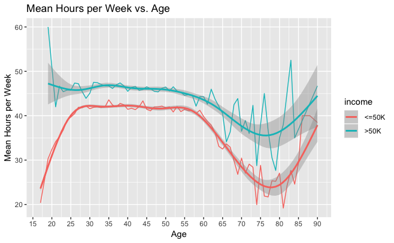

```r
ggplot(mapping = aes(x = age, y = hours_per_week),
       data = db.adult) +
  geom_line(mapping = aes(color = income),
            stat = 'summary',
            fun.y = mean) +
  geom_smooth(mapping = aes(color = income)) +
  scale_x_continuous(breaks = seq(10, 100, 5)) +
  labs(x = "Age",
       y = "Mean Hours per Week") +
  ggtitle("Mean Hours per Week vs. Age")
```

#### 3.4.2) “hours_w”

```r
summary(db.adult$hours_w)
```

```
 between_40_and_45  between_45_and_60  between_60_and_80
             16606               5790                857
      less_than_40       more_than_80
              6714                195
```

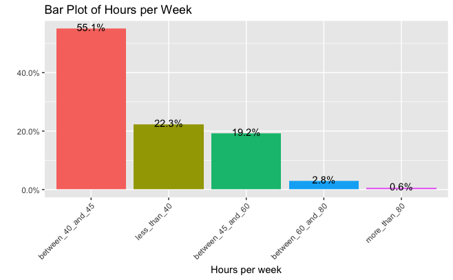

```r
db.adult <- within(db.adult, hours_w <- factor(hours_w, levels =
                                                   names(sort(table(hours_w),
                                                         decreasing = TRUE))))
ggplot(db.adult,
       aes(x = db.adult$hours_w, fill = db.adult$hours_w)) +
  geom_bar(aes(y = (..count..)/sum(..count..))) +
  geom_text(aes(label = scales::percent((..count..)/sum(..count..)),
                y = (..count..)/sum(..count..) ),
            stat = "count",
            vjust = 0.3) +
  labs(x = "Hours per week",
       y = "",
       fill = "Hours per week") +
  theme(legend.position = 'none',
        axis.text.x = element_text(angle = 45, hjust = 1)) +
  ggtitle("Bar Plot of Hours per Week") +
  scale_y_continuous(labels = percent)
```

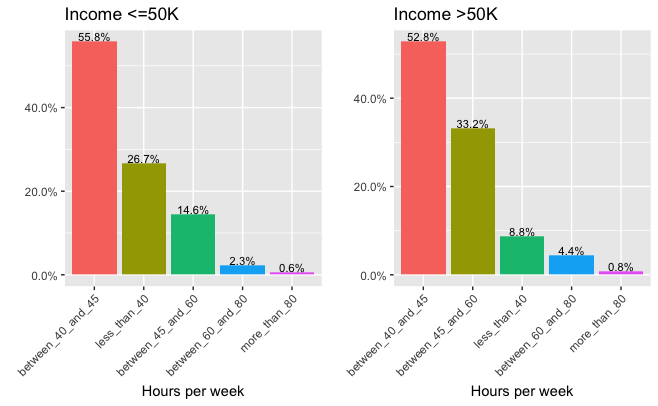

```r
lg_hpw <- lapply(levels(db.adult$income), function(v){

    df <- subset(db.adult, db.adult$income == v)

    df <- within(df, hours_w <- factor(hours_w,
                                       levels = names(sort(table(hours_w),
                                                           decreasing = TRUE))))

    ggplot(data = df,
         aes(x = hours_w,
             fill = hours_w)) +
      geom_bar(aes(y = (..count..)/sum(..count..))) +
      geom_text(aes(label = scales::percent((..count..)/sum(..count..)),
                    y = (..count..)/sum(..count..) ),
                stat = "count",
                vjust = -.1,
                size = 3) +
      labs(x = "Hours per week",
           y = "",
           fill = "Hours per week") +
      theme(legend.position = 'none',
            axis.text.x = element_text(angle = 45, hjust = 1)) +
      ggtitle(paste("Income", v, sep="")) +
      scale_y_continuous(labels = percent) })
grid.arrange(grobs = lg_hpw, ncol = 2)
```

We see that approximately the same percentage of people in both categories of “income” work between 40 and 45 hours a week, but the proportion of people with income>50K who work between 45 and 60 hours a week is 33.2% compared to 14.6% for that of people with income<=50K.

#### 3.5 The variable “native_region”

```r
summary(db.adult$native_region)
```

```
 Central-America     Central-Asia        East-Asia      Europe-East
            1226              142              304               85
     Europe-West      Outlying-US    South-America    United-States
             408              380              113            27504
```

The majority of people come from the United States and Central America.

Next we show a bar plot with the percentage of people belonging to each native region:

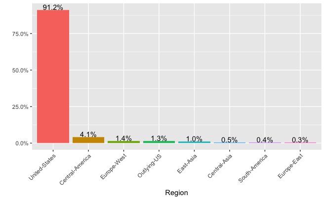

```r
db.adult$native_region <- factor(db.adult$native_region,
                                 levels =
                                     names(sort(table(db.adult$native_region),                                                 decreasing = TRUE)))
ggplot(db.adult,
       aes(x = db.adult$native_region, fill = db.adult$native_region)) +
  geom_bar(aes(y = (..count..)/sum(..count..))) +
  geom_text(aes(label = scales::percent((..count..)/sum(..count..)),
                y = (..count..)/sum(..count..) ),
            stat = "count",
            vjust = -.1) +
  labs(x = "Region",
       y = "",
       fill = "Regions") +
  theme(legend.position = 'none',
        axis.text.x = element_text(angle = 45, hjust = 1)) +
  scale_y_continuous(labels = percent)
```

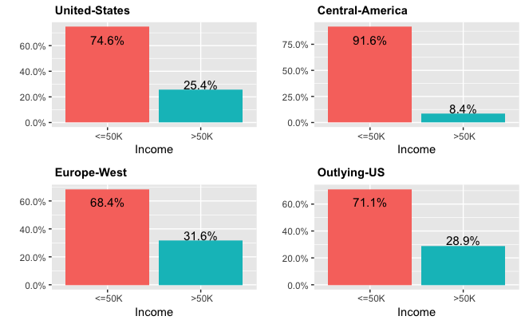

```r
lp_region <- lapply(levels(db.adult$native_region), function(v){

    df <- subset(db.adult, db.adult$native_region == v)

    ggplot(data = df,
           aes(x = income,
               fill = income)) +
      geom_bar(aes(y = (..count..)/sum(..count..))) +
      geom_text(aes(label = scales::percent((..count..)/sum(..count..)),
                    y = (..count..)/sum(..count..) ),
                stat = "count",
                vjust = c(2, -0.1),
                size = 4) +
      labs(x = "Income",
           y = "",
           fill = "Income") +
      ggtitle(v) +
      theme(legend.position = 'none',
            plot.title = element_text(size = 11, face = "bold")) +
      scale_y_continuous(labels = percent) })
grid.arrange(grobs = lp_region[1:4], ncol = 2)
```

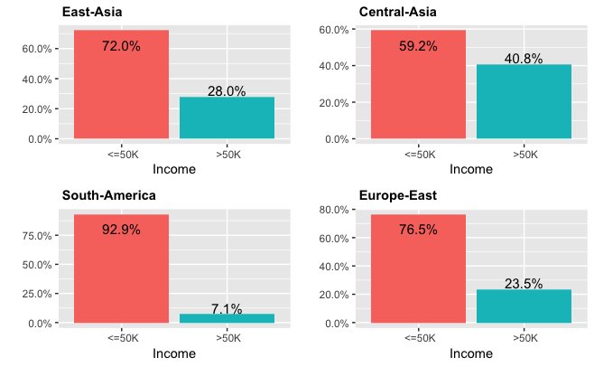

```r
grid.arrange(grobs = lp_region[5:8], ncol = 2)
```

As we can see from the graphics above, 40.8% of the people with Central-Asian origin earn more than 50K a year, which is the highest percentage among all native regions. However, we cannot rely completely on this inference, because there are only 142 participants with Central-Asian origin compared to 27504 people with domestic (US) roots. If we ignore the small number of individuals which comprise the samples for the rest of the native regions, we can make similar conclusions. Namely, the second place is for individuals of West-European descent - 31.6%, followed by Outlying-US with 28.9% and East Asia - with 28%. The fifth place is for people from the United States - 25.4%, followed by East-European descendents with 23.5% and the last place is for individuals with South-American origin - 7.1%. If we disregard the small number of observations for the non-US native regions, the latter results indicate that “income” is dependent on “native_region”.

### 3.6) The variable “workclass”

```r
summary(db.adult$workclass)
```

```
      Federal-gov         Local-gov           Private
              943              2067             22286
     Self-emp-inc  Self-emp-not-inc         State-gov
             1074              2499              1279
      Without-pay
               14
```

```r
table(db.adult$workclass)
```

```
      Federal-gov         Local-gov           Private
              943              2067             22286
     Self-emp-inc  Self-emp-not-inc         State-gov
             1074              2499              1279
      Without-pay
               14
```

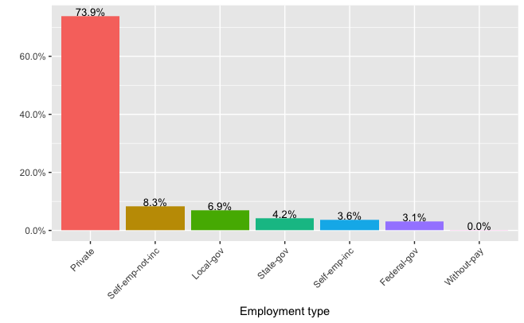

```r
db.adult$workclass <- factor(db.adult$workclass,
                             levels =
                                     names(sort(table(db.adult$workclass),                                                    decreasing = TRUE)))
ggplot(db.adult,
       aes(x = db.adult$workclass, fill = db.adult$workclass)) +
  geom_bar(aes(y = (..count..)/sum(..count..))) +
  geom_text(aes(label = scales::percent((..count..)/sum(..count..)),
                y = (..count..)/sum(..count..) ),
            stat = "count",
            vjust = -.1,
            size = 3.5) +
  labs(x = "Employment type",
       y = "",
       fill = "Employment type") +
  theme(legend.position = 'none',
        axis.text.x = element_text(angle = 45, hjust = 1)) +
  scale_y_continuous(labels = percent)
```

```r
nrow(subset(db.adult, db.adult$workclass == " Never-worked"))
```

```
[1] 0
```

```r
nrow(subset(db.adult, db.adult$workclass == " Without-pay" &
                      db.adult$income == " >50K"))
```

```
[1] 0
```

```r
nrow(subset(db.adult, db.adult$workclass == " Without-pay" &
                      db.adult$income == " <=50K"))
```

```
[1] 14
```

Therefore, in order to make the plots more readable and meaningful, we exclude the factor levels " Never-worked" and " Without-pay“. We do this in the following way:

First we create the character vector “modified.work”, whose elements are the levels of the nominal variable “workclass”;

Then we transform the vector by excluding from it the elements " Never-worked" and " Without-pay“

```r
modified.work <- levels(db.adult$workclass)
modified.work
```

```
[1] " Private"          " Self-emp-not-inc" " Local-gov"
[4] " State-gov"        " Self-emp-inc"     " Federal-gov"
[7] " Without-pay"
```

```r
modified.work <- modified.work[!is.element(modified.work, c(" Never-worked", " Without-pay"))]
modified.work
```

```
[1] " Private"          " Self-emp-not-inc" " Local-gov"
[4] " State-gov"        " Self-emp-inc"     " Federal-gov"
```

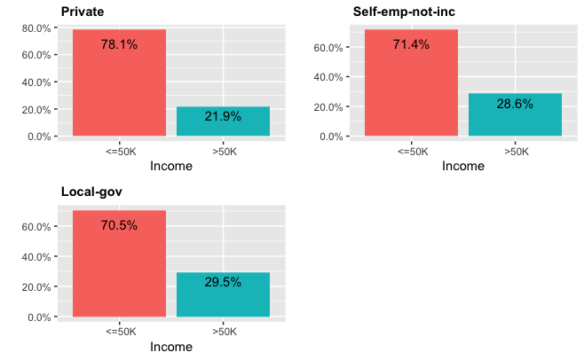

```r
lg.workclass.mod <- lapply(modified.work, function(v){

  ggplot(data = subset(db.adult, db.adult$workclass == v),
         aes(x = subset(db.adult, db.adult$workclass == v)$income,
             fill = subset(db.adult, db.adult$workclass == v)$income)) +
    geom_bar(aes(y = (..count..)/sum(..count..))) +
    geom_text(aes(label = scales::percent((..count..)/sum(..count..)),
                y = (..count..)/sum(..count..) ),
              stat = "count",
              vjust = c(2, 1.5)) +
    labs(x = "Income",
         y = "",
         fill = "Income") +
    ggtitle(v) +
    theme(legend.position = 'none',
          plot.title = element_text(size = 11, face = "bold")) +
    scale_y_continuous(labels = percent) })
grid.arrange(grobs = lg.workclass.mod[1:3], ncol = 2)
```

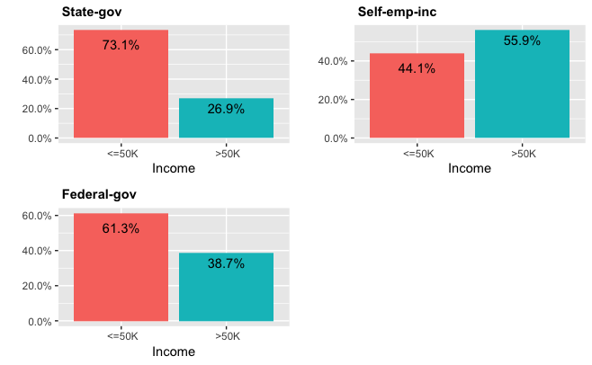

```r
grid.arrange(grobs = lg.workclass.mod[4:6], ncol = 2)
```

From the graphs above, we can see that the percentage of individuals having an income of more than 50K is biggest for the category “Self-emp-inc” (self-employed people with income) – 55.9%. The group with the second highest percentage of people earning more than 50K is that of federal government employees. There is no significant difference between the categories " Local-gov" (local government), " Self-emp-not-inc" (self-employed individuals without income) and " State-gov" (state government jobs) - about 27-28% of the workers in these branches have an annual pay of more than 50000$. In the private sector only about 22% of the people earn more than 50K a year. These results demonstrate that there is a relationship between the variables “income” and “workclass”.

#### 3.7) The variable “education”

```r
summary(db.adult$education)
```

```
         10th          11th          12th       1st-4th       5th-6th
          820          1048           377           151           288
      7th-8th           9th    Assoc-acdm     Assoc-voc     Bachelors
          557           455          1008          1307          5044
    Doctorate       HS-grad       Masters     Preschool   Prof-school
          375          9840          1627            45           542
 Some-college
         6678
```

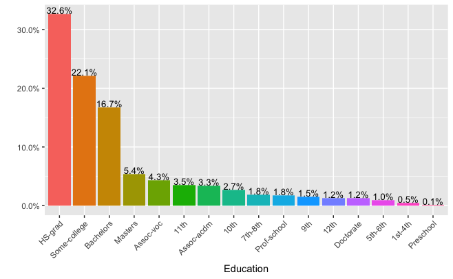

```r
db.adult$education <- factor(db.adult$education,
                                 levels =
                                     names(sort(table(db.adult$education),                                                    decreasing = TRUE)))
ggplot(db.adult,
       aes(x = db.adult$education, fill = db.adult$education)) +
  geom_bar(aes(y = (..count..)/sum(..count..))) +
  geom_text(aes(label = scales::percent((..count..)/sum(..count..)),
                y = (..count..)/sum(..count..) ),
            stat = "count",
            vjust = -.1,
            size = 3.5) +
  labs(x = "Education",
       y = "",
       fill = "Education") +
  theme(legend.position = 'none',
        axis.text.x = element_text(angle = 45, hjust = 1)) +
  scale_y_continuous(labels = percent)
```

```r
nrow(subset(db.adult, db.adult$education == "Preschool" & db.adult$income == " >50K"))
```

```
[1] 0
```

```r
modified.edu <- levels(db.adult$education)
modified.edu
```

```
 [1] " HS-grad"      " Some-college" " Bachelors"    " Masters"
 [5] " Assoc-voc"    " 11th"         " Assoc-acdm"   " 10th"
 [9] " 7th-8th"      " Prof-school"  " 9th"          " 12th"
[13] " Doctorate"    " 5th-6th"      " 1st-4th"      " Preschool"
```

```r
modified.edu <- modified.edu[!is.element(modified.edu, " Preschool")]
modified.edu
```

```
 [1] " HS-grad"      " Some-college" " Bachelors"    " Masters"
 [5] " Assoc-voc"    " 11th"         " Assoc-acdm"   " 10th"
 [9] " 7th-8th"      " Prof-school"  " 9th"          " 12th"
[13] " Doctorate"    " 5th-6th"      " 1st-4th"
```

```r
?lapply
```

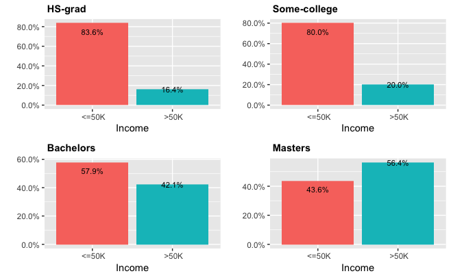

```r
lg.mod.edu <- lapply(modified.edu, function(v){

  ggplot(data = subset(db.adult, db.adult$education == v),
         aes(x = subset(db.adult, db.adult$education == v)$income,
             fill = subset(db.adult, db.adult$education == v)$income)) +
    geom_bar(aes(y = (..count..)/sum(..count..))) +
    geom_text(aes(label = scales::percent((..count..)/sum(..count..)),
                  y = (..count..)/sum(..count..) ),
             stat = "count",
             vjust =  c(2, 0.5),
             size = 3) +
    labs(x = "Income",
         y = "",
         fill = "Income") +
    ggtitle(v) +
    theme(legend.position = 'none',
          plot.title = element_text(size = 11, face = "bold")) +
    scale_y_continuous(labels = percent) })
grid.arrange(grobs = lg.mod.edu[1:4], ncol = 2)
```

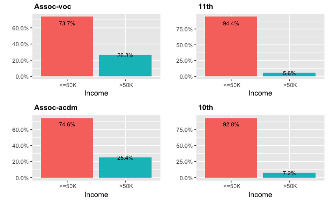

```r
grid.arrange(grobs = lg.mod.edu[5:8], ncol = 2)
```

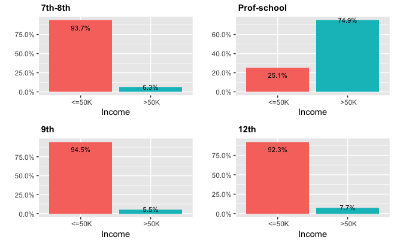

```r
grid.arrange(grobs = lg.mod.edu[9:12], ncol = 2)
```

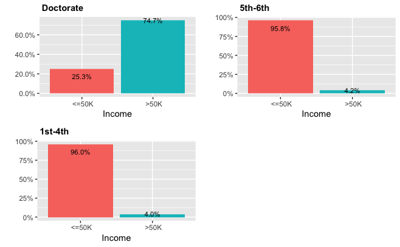

```r
grid.arrange(grobs = lg.mod.edu[13:15], ncol = 2)
```

The categories " 1st-4th“,” 5th-6th“,” 7th-8th“,” 9th“,” 10th“,” 11th" and " 12th" have a very small percentage of people with income greater than 50K a year. The percentage of people with a high school degree who earn more than 50K is also relatively small - 16.4%. 20% of the individuals in the category " Some-college" earn more than 50K. The biggest percentage of employees (74.9%), who have an annual income higher than 50K, belongs to the category " Prof-school“. The” Doctorate" group is next with 74.7%, followed by the categories " Masters" - 56.4% and " Bachelors" - 42.1%. These results clearly indicate that there is a relationship between education and income. In order to demonstrate this correlation visually, we show one more graph - a conditional density plot of income versus education number (“education_num”):

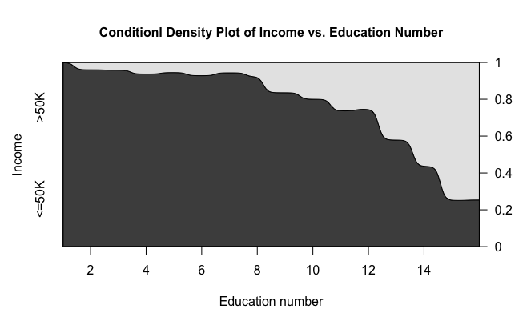

```r
cd_plot(x = db.adult$education_num,
        y = db.adult$income,
        xlab = "Education number",
        ylab = "Income",
        main = "Conditionl Density Plot of Income vs. Education Number")
```